# Ошибки I и II рода

Автор

Черкасова Полина

## Требования к сдаче и оформлению задания

Заполните этот qmd-файл кодом и ответами. Порядок сдачи задания описан в README.md, на Stepik или Google-class.

1. Старайтесь соблюдать единый стиль оформления и структуру отчёта. Не оставляйте лишние чанки кода, текст или комментарии, которые не относятся к решению задания.
2. Основные результаты представьте на графиках и объясните в тексте. Отдельные таблицы результатов не требуются. Не оставляйте необработанный консольный вывод или отдельные числа без пояснений.
3. Графики должны быть достаточно крупными, с читаемыми русскими подписями, содержательным заголовком и правильно названными осями. Не используйте фон ggplot2 по умолчанию.
4. Ответы на вопросы и интерпретации результатов, включая графики, пишите обычным текстом, а не комментариями к коду. Код и его вывод не заменяют ответ на вопрос.
5. Сохраняйте исходную структуру проекта в репозитории. Не добавляйте лишние файлы, которые не относятся к проекту или выполнению заданий.
6. Оформление коммитов и веток на GitHub должно соответствовать общим правилам для всех курсов Института биоинформатики.

## О задании

На занятии мы оценивали ошибки I и II рода. Теперь с помощью симуляций вы **графически исследуете**, как вероятности этих ошибок у двухвыборочного t-теста зависят от уровня значимости, объёма выборки и распределения данных.

Для этого вы проведёте серии симуляций для разных **сочетаний параметров**.

**Результат выполнения домашнего задания: шесть графиков зависимости ошибки I или II рода от $\alpha$ и их интерпретация, выводы.**

## Условия

> Если условия не будут понятны с первого раза, то посмотрите на таблицу в разделе **“Сочетания условий”**.
1. Для сравнения средних двух независимых групп используйте `t.test()`.
2. Объём выборки в каждой из двух групп ($X$ и $Y$) должен быть одинаковым: **$n$ = 3, 10, 30, 100**. Здесь $n$ – объём **одной** выборки. В одном повторении сравниваются две выборки, то есть всего $2n$ наблюдений.
3. Исследуйте **нормальное, равномерное и экспоненциальное распределения**.
4. Проверяйте гипотезы $H_0: \mu_X = \mu_Y$ и $H_a: \mu_X \ne \mu_Y$. Для каждого типа распределения и объёма выборки рассмотрите два сценария:
- **$H_0$ верна:** генерируйте две независимые выборки из распределения с одинаковыми параметрами для обеих групп. Средние генеральных совокупностей равны.
- **$H_0$ неверна:** генерируйте две независимые выборки из распределений выбранного типа, выбрав параметры так, чтобы средние генеральных совокупностей различались.

> **Параметры распределений выберите один раз для каждого типа распределения и сценария.** В отчёте укажите выбранные параметры, истинные средние и истинные стандартные отклонения обеих групп. Затем сохраняйте параметры при изменении $n$ и $\alpha$.

> Рекомендуем для разных типов распределений задать одинаковое истинное среднее группы $X$ и одинаковое истинное среднее группы $Y$ в соответствующем сценарии.
5. Используйте уровни значимости **$\alpha = 0.01, 0.02, \ldots, 0.20$ с шагом 0.01**.
6. Для каждого сочетания типа распределения, объёма выборки и сценария проведите одну серию из **1000 повторений**. Вероятность ошибки оценивайте по её частоте в серии.

### Сочетания условий

**Переберите все сочетания:** 2 сценария × 3 типа распределений × 4 объёма выборки × 20 уровней значимости. В ячейках указан диапазон $\alpha$.

| Сценарий | Тип распределения | $n = 3$ | $n = 10$ | $n = 30$ | $n = 100$ |
| --- | --- | --- | --- | --- | --- |
| **$H_0$ верна** | Нормальное | $[0.01, 0.20]$ | $[0.01, 0.20]$ | $[0.01, 0.20]$ | $[0.01, 0.20]$ |
|  | Равномерное | $[0.01, 0.20]$ | $[0.01, 0.20]$ | $[0.01, 0.20]$ | $[0.01, 0.20]$ |
|  | Экспоненциальное | $[0.01, 0.20]$ | $[0.01, 0.20]$ | $[0.01, 0.20]$ | $[0.01, 0.20]$ |
| **$H_0$ неверна** | Нормальное | $[0.01, 0.20]$ | $[0.01, 0.20]$ | $[0.01, 0.20]$ | $[0.01, 0.20]$ |
|  | Равномерное | $[0.01, 0.20]$ | $[0.01, 0.20]$ | $[0.01, 0.20]$ | $[0.01, 0.20]$ |
|  | Экспоненциальное | $[0.01, 0.20]$ | $[0.01, 0.20]$ | $[0.01, 0.20]$ | $[0.01, 0.20]$ |

Каждая ячейка с диапазоном $\alpha$ соответствует одной серии из **1000 повторений** для указанного сценария, типа распределения и объёма выборки. **Один и тот же набор p-значений этой серии используйте для всех 20 уровней $\alpha$: новые выборки для каждого $\alpha$ генерировать не нужно.**

Всего получится **24 серии**. Для каждой серии оцените вероятность ошибки I или II рода (в зависимости от сценария) при всех **20 уровнях $\alpha$**. В результате получите по **240 оценок для каждого типа ошибки (сценария)**.

## Проведение симуляции

```r
library(tidyverse)
```

1. **Задайте seed один раз перед симуляциями**.

```r
set.seed(42)
```

2. В каждом повторении генерируйте две новые независимые выборки, применяйте t-тест и сохраняйте p-значение.
3. Проведите симуляции и сохраните оценки вероятностей ошибок I или II рода для каждого сочетания типа распределения, объёма выборки, сценария и уровня значимости.

```r
# Параметры для сценария "H0 верна" (средние равны)
params_h0_true <- list(
  normal = list(
    dist = "norm",
    x_mean = 0, x_sd = 1,
    y_mean = 0, y_sd = 1
  ),
  uniform = list(
    dist = "unif",
    x_min = 0, x_max = 1,
    y_min = 0, y_max = 1
  ),
  exponential = list(
    dist = "exp",
    x_rate = 1,
    y_rate = 1
  )
)

# Параметры для сценария "H0 неверна" (средние различаются)
params_h0_false <- list(
  normal = list(
    dist = "norm",
    x_mean = 0, x_sd = 1,
    y_mean = 1, y_sd = 1
  ),
  uniform = list(
    dist = "unif",
    x_min = 0, x_max = 1,
    y_min = 0.5, y_max = 1.5
  ),
  exponential = list(
    dist = "exp",
    x_rate = 1,
    y_rate = 0.5
  )
)
```

```r
distributions <- c("normal", "uniform", "exponential")
scenarios     <- c("h0_true", "h0_false")
sample_sizes  <- c(3, 10, 30, 100)
alpha_levels  <- seq(0.01, 0.20, by = 0.01)

results_list <- list()
idx <- 1

# Перебор сочетаний
for (dist in distributions) {
  for (scen in scenarios) {
    for (n in sample_sizes) {

      # 1. Выбор параметров
      params <- if (scen == "h0_true") params_h0_true[[dist]] else params_h0_false[[dist]]

      # 2. Генерация выборок
      p_values <- replicate(1000, {
        x <- if (params$dist == "norm") rnorm(n, params$x_mean, params$x_sd)
             else if (params$dist == "unif") runif(n, params$x_min, params$x_max)
             else rexp(n, params$x_rate)

        y <- if (params$dist == "norm") rnorm(n, params$y_mean, params$y_sd)
             else if (params$dist == "unif") runif(n, params$y_min, params$y_max)
             else rexp(n, params$y_rate)

        t.test(x, y)$p.value # t-тест
      })

      # 3. Вероятность ошибки в зависимости от значения alpha
      for (alpha in alpha_levels) {
        # Ошибка I рода: p < alpha. Ошибка II рода: p >= alpha
        err_rate <- if (scen == "h0_true") mean(p_values < alpha) else mean(p_values >= alpha)

        results_list[[idx]] <- data.frame(
          distribution = dist,
          scenario     = scen,
          n            = n,
          alpha        = alpha,
          error_rate   = err_rate
        )
        idx <- idx + 1
      }
    }
  }
}

# Объединение в общий пул данных
results <- bind_rows(results_list)

results$distribution <- factor(results$distribution,
  levels = c("normal", "uniform", "exponential"),
  labels = c("Нормальное", "Равномерное", "Экспоненциальное"))
results$scenario <- factor(results$scenario,
  levels = c("h0_true", "h0_false"),
  labels = c("Ошибка I рода (H0 верна)", "Ошибка II рода (H0 неверна)"))
```

## Постройте графики

1. Постройте шесть графиков: **три распределения × два типа ошибок**. Допустимы шесть отдельных рисунков или один общий рисунок из шести панелей.
2. На каждом графике по оси **X** отложите $\alpha$, по оси **Y** – вероятность ошибки I или II рода. Покажите **четыре кривые**, соответствующие объёмам выборки $n = 3, 10, 30, 100$.
3. Используйте одинаковые цвета для одинаковых $n$ и одинаковые границы осей для одного типа ошибки.

> На графиках для ошибки I рода добавьте пунктирную линию **$y = \alpha$** для сравнения с заданным уровнем значимости.

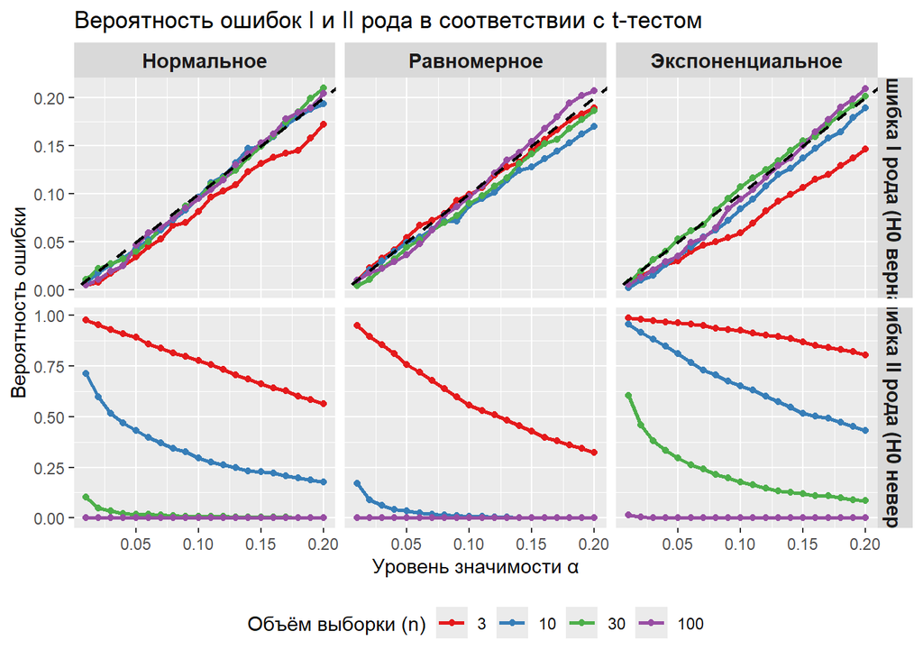

```r
ggplot(results, aes(x = alpha, y = error_rate, color = factor(n))) +
  geom_line(linewidth = 1) +
  geom_point(size = 1.5) +

  geom_abline(
    data = data.frame(scenario = "Ошибка I рода (H0 верна)"),
    mapping = aes(intercept = 0, slope = 1),
    linetype = "dashed",
    color = "black",
    linewidth = 0.8
  ) +

  facet_grid(scenario ~ distribution, scales = "free_y") +

  scale_color_brewer(palette = "Set1", name = "Объём выборки (n)") +

  labs(
    title = "Вероятность ошибок I и II рода в соответствии с t-тестом",
    x = "Уровень значимости α",
    y = "Вероятность ошибки"
  ) +

  theme(
    legend.position = "bottom",
    strip.text = element_text(face = "bold", size = 11) # Жирный текст заголовков панелей
  )
```

## Выводы

Напишите выводы, попутно ответив на вопросы:

1. Насколько оценённая вероятность ошибки I рода близка к $\alpha$ в каждом случае? Видны ли отклонения для каких-либо распределений и объёмов выборки? Если видны, в какую сторону?
2. Как меняется вероятность ошибки II рода при изменении $\alpha$ и $n$? Как вы думаете, почему?
3. Чем различаются результаты для трёх распределений?
4. Почему оценённая частота ошибки I рода может не совпадать с $\alpha$?

## Дополнительное задание

Выберите один тип распределения и объём выборки $n=10$. Для каждого из двух сценариев возьмите параметры из основного задания и рассмотрите ещё два варианта, изменяя один выбранный параметр распределения. Укажите, какой параметр и в какой группе или группах вы изменяете.

Остальные параметры распределения, объём выборки, уровни $\alpha$ и число повторений оставьте прежними.

**Постройте два графика**: для ошибки I рода и для ошибки II рода. На каждом покажите три кривые – исходный вариант (из основного задания) и два изменённых.

Какие изменения вы наблюдаете? Почему?